# Supermarket

Analiza czynników istotnie wpływających na satysfakcje klienta

# Wstęp

## Opis problemu

Celem projektu jest eksploracja historycznych danych dotyczących sprzedaży w supermarketach oraz identyfikacja czynników mogących istotnie wpływać na ocenę satysfakcji klientów dotyczącą ich ogólnego doświadczenia zakupowego.

## Baza danych

Podstawą analizy był zbiór danych supermarket_new, zawierający dane pochodzące z jednej z historycznych sprzedaży firm supermarketów, która została zarejestrowana w 3 różnych oddziałach przez 3 miesiące.

## Zmienne

Zbiór danych supermarket_new zawiera następujące zmienne:

Tabela 1. Opis zmiennych w zbiorze danych *supermarket_new*

| Zmienna | Opis |
| --- | --- |
| Invoice id | Numer identyfikacyjny faktury sprzedaży (unikalna wartość) |
| Branch | Oddział supercentrum (3 oddziały oznaczone literami A, B, C) |
| City | Lokalizacja supercentrów |
| Customer type | Typ klienta (z kartą członkowską lub bez) |
| Gender | Płeć klienta |
| Product line | Ogólne grupy kategoryzacji przedmiotów |
| Unit price | Cena każdego produktu w $ |
| Quantity | Liczba produktów zakupionych przez klienta |
| Tax | Opłata podatkowa w wysokości 5% dla klienta dokonującego zakupu |
| Total | Cena całkowita z podatkiem |
| Date | Data zakupu (rekord dostępny od 01.2019 do 03.2019) |
| Time | Czas zakupu (od 10:00 do 21:00) |
| Payment | Płatność wykorzystana przez klienta do zakupu (gotówka, karta kredytowa lub portfel elektroniczny) |
| COGS | Koszt sprzedanych towarów |
| Gross margin percentage | Procentowa marża brutto |
| Gross income | Dochód brutto |
| Rating | Ocena stratyfikacji klientów (w skali od 1 do 10) |

```
## 'data.frame':    1000 obs. of  17 variables:
##  $ Invoice.ID             : chr  "750-67-8428" "226-31-3081" "631-41-3108" "123-19-1176" ...
##  $ Branch                 : chr  "A" "C" "A" "A" ...
##  $ City                   : chr  NA "Naypyitaw" "Yangon" "Yangon" ...
##  $ Customer.type          : chr  "Member" "Normal" "Normal" "Member" ...
##  $ Gender                 : chr  "Female" "Female" "Male" "Male" ...
##  $ Product.line           : chr  "Health and beauty" "Electronic accessories" "Home and lifestyle" "Health and beauty" ...
##  $ Unit.price             : num  74.7 15.3 46.3 58.2 86.3 ...
##  $ Quantity               : int  7 5 7 8 7 7 6 10 2 3 ...
##  $ Tax.5.                 : num  26.14 3.82 16.22 23.29 30.21 ...
##  $ Total                  : num  549 80.2 340.5 489 634.4 ...
##  $ Date                   : chr  "1/5/2019" "3/8/2019" "3/3/2019" "1/27/2019" ...
##  $ Time                   : chr  "13:08:00" "10:29:00" "13:23:00" "20:33:00" ...
##  $ Payment                : chr  "Ewallet" "Cash" "Credit card" "Ewallet" ...
##  $ cogs                   : num  522.8 76.4 324.3 465.8 604.2 ...
##  $ gross.margin.percentage: num  4.76 4.76 4.76 4.76 4.76 ...
##  $ gross.income           : num  26.1 NA 16.2 23.3 30.2 ...
##  $ Rating                 : num  NA 9.6 NA 8.4 5.3 4.1 5.8 8 7.2 5.9 ...
```

Funkcja *str* pozwala na określenie struktury analizowanych danych. Dzięki niej można określić typ analizowanych danych, całkowitą ich ilość (1000) i ilość zmiennych (17). Analiza pozwala zauważyć, iż zmienna Date zawierająca datę zakupu nie jest wyrażona w odpowiednim formacie. Przy użyciu pakietu *lubridate* nastąpi zmiana formatu z character na date.

# Data Cleansing & Data Wrangling

Celem tego części jest kompleksowe oczyszczenie i przygotowanie danych z pliku “supermarket_new.csv”. W szczególności skupimy się na identyfikacji i uzupełnieniu brakujących wartości w kluczowych kolumnach: City, Rating oraz gross.income. Dzięki zastosowaniu odpowiednich technik eksploracji, analizy oraz imputacji danych, walidacji końcowy zbiór będzie spójny, kompletny i gotowy do dalszych analiz.

```
## [1] 400
```

W zbiorze zidentyfikowano 400 brakujących rekordów. W kolejnych krokach zbadano zbadano, które kolumny zawierające wartości NA, ile ich jest, jaki procent stanowią oraz jak je uzupełnić.

```
## [1] 2.35
```

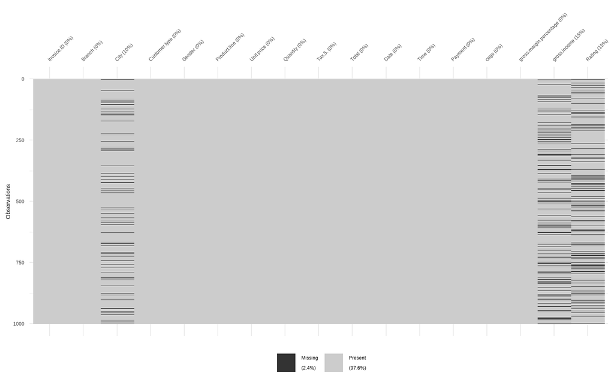

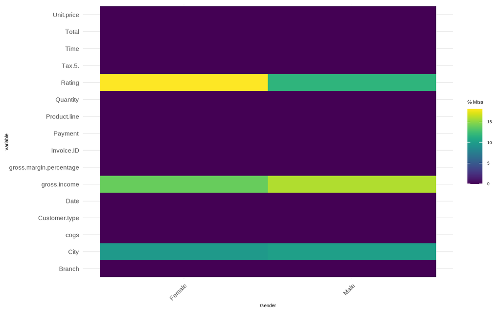

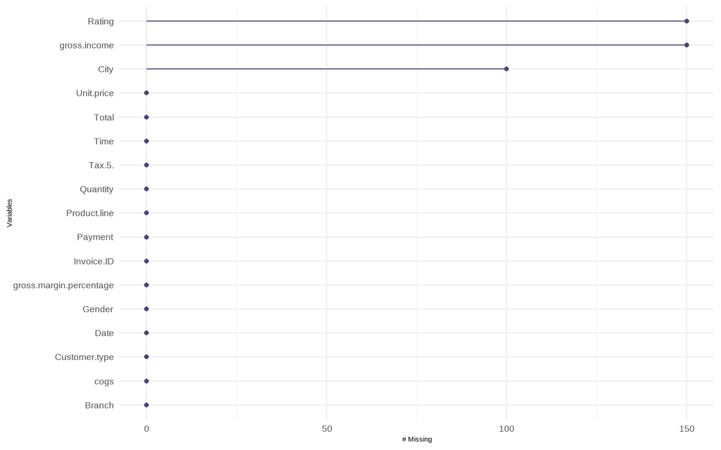

Wyznaczono następujące braki w kolumnach: Rating (150), City (100), gross.income (150). Sprawdzono także -procent braków w stosunku do całego zbioru danych -podsumowano braki dla poszczególnych kolumn - zwizualizowano braki w danych, również w kontekście kolumny Gender - przedstawiono współwystępowanie braków w różnych kolumnach.

```r
# 3. Eksploracja danych
table(super$Gender)
```

```
##
## Female   Male
##    501    499
```

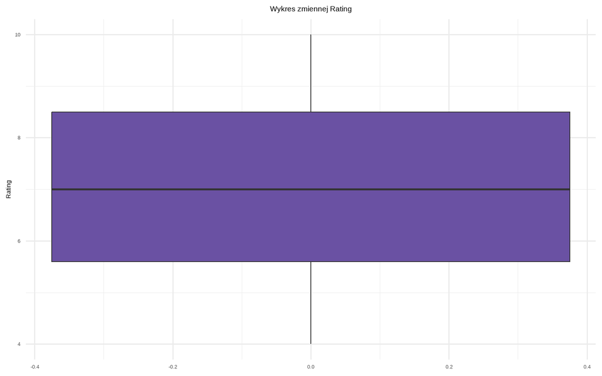

Kolejno podjęto się eksploracji danych.

```
## super_City_hd
##  Mandalay Naypyitaw    Yangon
##       332       327       341
```

```
##
##  Mandalay Naypyitaw    Yangon
##       304       291       305
```

W przedostatnim kroku zostały uzupełnione braki w danych, zastępując je kolejnymi dostępnymi wartościami. Dodana została wartość zapasowa na końcu oraz identyfikacja braków w wektorze. Następnie zastąpione zostały braki kolejnymi wartościami i zostały zaktualizowane indeksy braków. Kolejno: - zwrot oryginalnej długości wektora - sortowanie kolumny City według Branch - posortowanie danych w kolumnie City - uzupełnienie braków w City za pomocą funkcji segImpute - podsumowanie nowej kolumny City oraz podsumowanie oryginalnej kolumny City.

W tym kroku została dokonana imputacja braków metodą KNN. Dla kolumny Rating zastosowano imputację braków metodą K-Nearest Neighbours, następnie zastąpiono oryginalną kolumnę imputowaną wersją.

W ostatnim kroku przy formowaniu założeń walidacyjnych zauważono zależności między kolumnami i na ich podstawie uzupełniono braki w 150 rekordach w kolumnie gross.income. Co pozwoliło na uzupełnienie braków z większą precyzją.

```
##   name items passes fails nNA error warning
## 1   V1  1000   1000     0   0 FALSE   FALSE
## 2   V2  1000    684   316   0 FALSE   FALSE
##                                         expression
## 1 abs(gross.income - (Total - cogs)) <= 0.00000001
## 2          Total == Unit.price * Quantity + Tax.5.
```

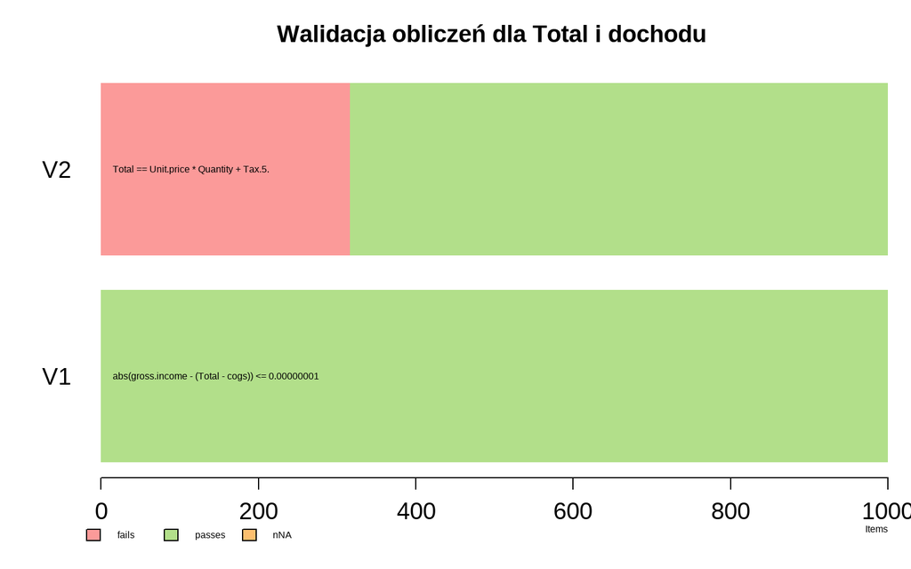

W procesie walidacji dostrzeżono nieścisłości dla ponad 300 rekordów w odniesnieu do wartości Total. Zatem nadpisano tę kolumnę prawidłowym wzorem na jej zawartość na podstawie wartości z pozostałych kolumn. Proces oczyszczania oraz walidacji danych został zakończony. Zastosowane metody pozwoliły na uzupełnienie brakujących wartości w spójny i logiczny sposób. Zbiór danych jest teraz kompletny i gotowy do dalszych analiz, co pozwala na precyzyjne wyciąganie wniosków i tworzenie modeli analitycznych.

# Wizualizacje

W tej części zajęto się opracowaniem wizualizacji analizowanych danych.

## Wizualizacja gęstości ocen względem zmiennych

Poniżej przedstawiono wizualizacje gęstości ocen klientów (rating) w odniesieniu do różnych cech, takich jak oddział sklepu, płeć, typ klienta czy metoda płatności. Wizualizacje gęstości umożliwiają zobrazowanie, jak oceny klientów rozkładają się w zależności od wybranych zmiennych. Wykres gęstości ilustruje rozkład zmiennej na osi numerycznej, gdzie wyższe wartości wskazują na obszary większego zagęszczenia. O bszary te oznaczają większą liczbę obserwacji dla danych wartości, co pozwala lepiej zrozumieć wzorce i różnice w danych.

### Wykres gęstości ocen klientów względem filii sklepu

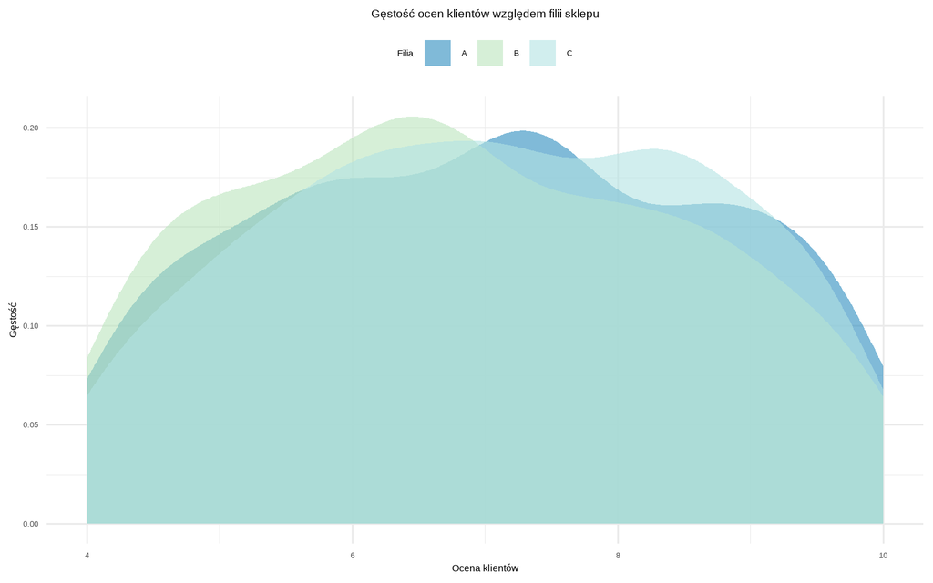

### Wykres gęstości ocen klientów względem płci

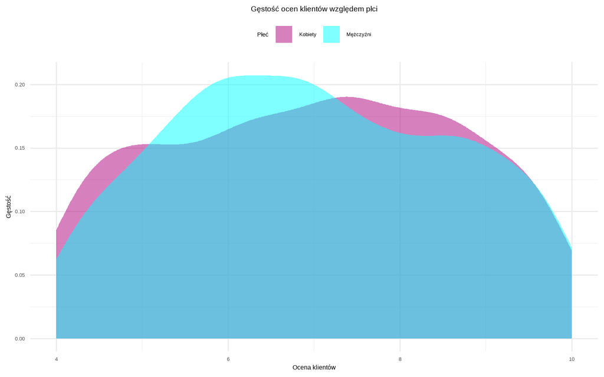

### Wykres gęstości ocen klientów względem typu klienta

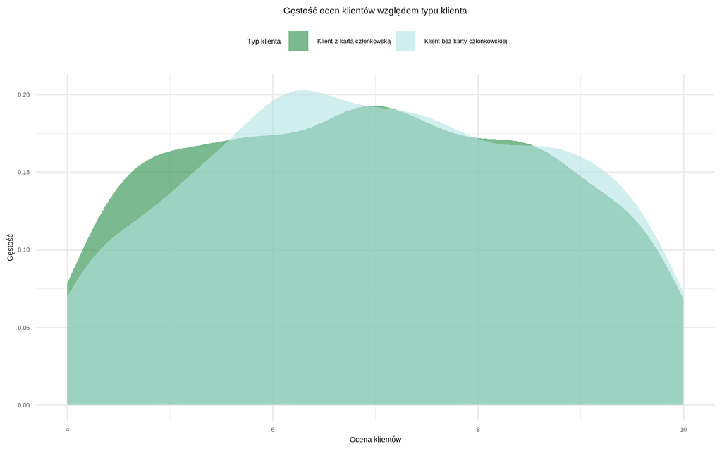

### Wykres gęstości ocen klientów względem metody płatności

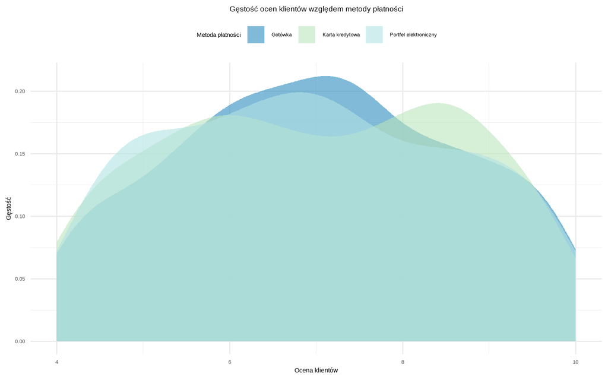

Na powyższym wykresie można zauważyć spójność ocen u klientów płacących gotówką lub portfelem elektrocznicznym. Szczyt gęstości dla tych grup znajduje się w okolicach 7. Klienci, którzy jako metodę płatności wybrali kartę kredytową częściej oceniali ogólne doświadczenia zakupowe w okolicach 8, na co wskazuje szczyt gęstości.

## Wizualizacja rozkładu ocen klietów względem kategorii zakupowanych produktów

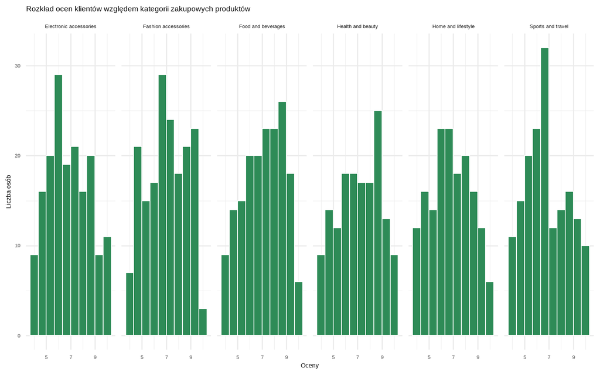

## Wizualizacja średniej ocen zadowolenia klientów dla poszczególnych miast

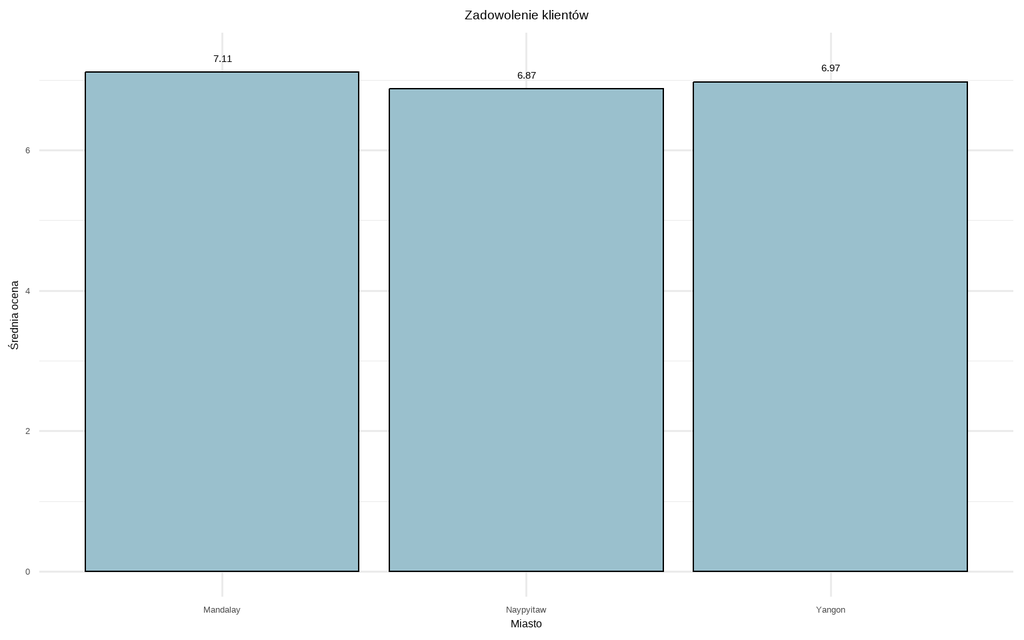

Średnia ocen zadowolenia z zakupów dla poszczególnych miast okazała sie zbliżona. Jednakże można zauważyć, że najwyżej klienci oceniali swoje doświadczenie w Mandalay, następnie w Yangon a kolejno w Naypyitaw. Wykres ilustruje, że lokalizacja miała raczej niewielki wpływ na ich satysfakcję oraz, że w każdej miejscowości klienci oceniają swój proces zakupowy jako zadowalający.

### Wykres procentowy udziału linii produktowych w całkowitych kosztach.

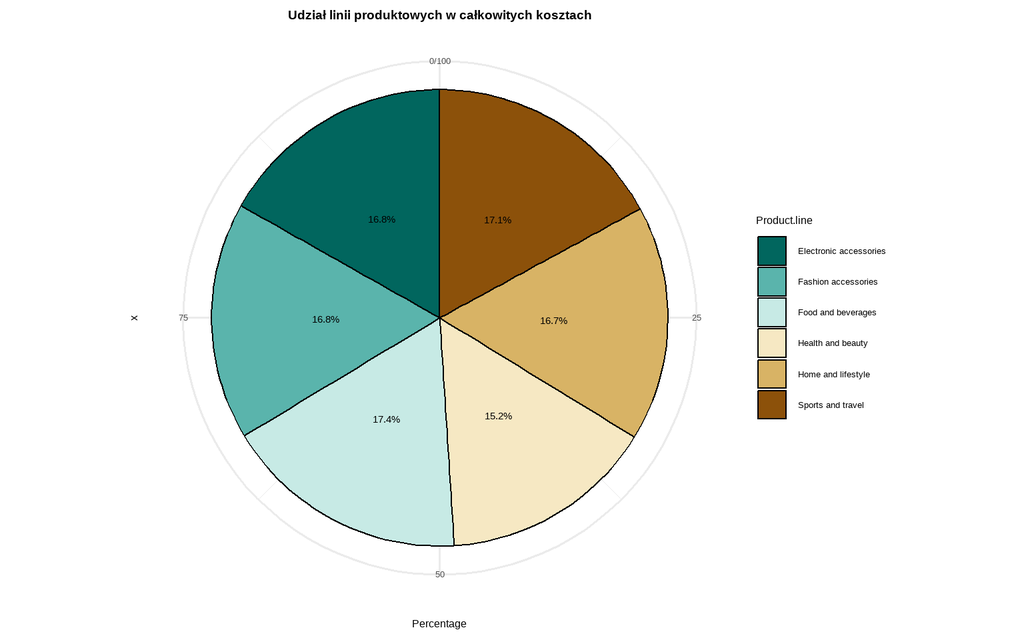

Procentowy udział linii produktowych w całych kosztach jest zbliżony do siebie. Największy udział linii produktowej odnosi się do jedzenia i napojów natomiast najmniejszy udział ma zdrowie i uroda. Można również zauważyć, że tak sam udział maakcesoria związane z modą jak i akcesoria elektroniczne.

### Liczba zakupionych produktów w podziale na sposób płatności.

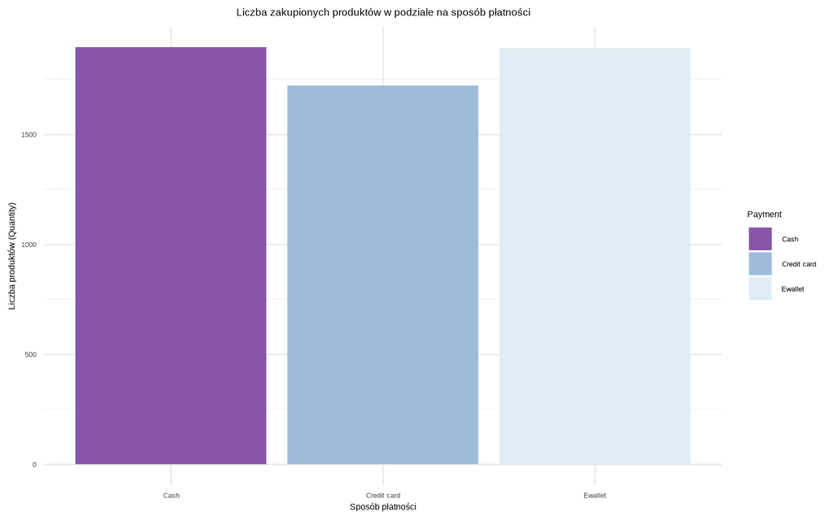

Z powyższego wykresu można wywnioskować, że najwięcej produktów kupuje się kolejno: - płacąc gotówką, - płacąc ewalletem - płacąc kartą kredytową. Są to dość zaskakujące wnioski zwazając na to, że coraz bardziej odchodzi się od płacenia gotówką.

## Wizualizacja dziennych przychodów w oddziałach z podziałem na miesiące

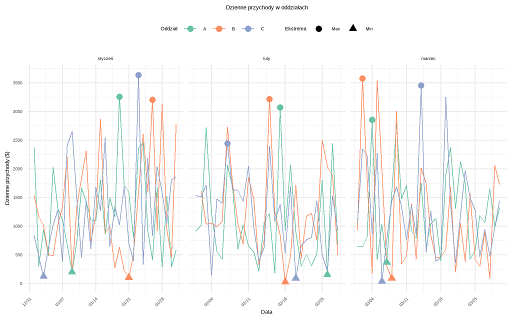

## Wizualizacja przedstawiająca najbardzej dochodowe pory dnia

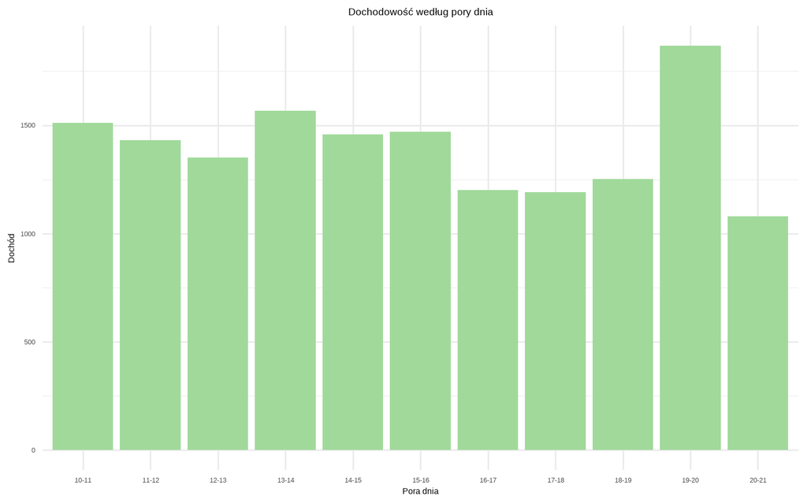

Na podstawie przedstawionego wykresu można ustalić, że najbardziej dochodwy okres dla supermarketu występuje między godzinami 19 a 20. Przedstawiony wykres użyteczny może okazać się przy ustalaniu i modyfikacji godzin otwarcia sklepu np. w dni świąteczne, bądź weekendy. Najmniej dochodowy moment dla supermarketu znajduje się w ostatniej godzinie otwarcia sklepu.

# Statystyki opisowe

## Dochód

Statystyki rozkładu gross.income wg filii.

| Filia | Min | Max | Średnia | Odchylenie std. | Mediana | Q1 | Q3 | Skośność | Kurtoza |
| --- | --- | --- | --- | --- | --- | --- | --- | --- | --- |
| A | 0.60 | 49.49 | 14.87 | 11.03 | 11.47 | 6.55 | 21.87 | 0.90 | 2.98 |
| B | 0.89 | 48.69 | 15.23 | 11.55 | 12.04 | 5.71 | 22.17 | 0.88 | 2.83 |
| C | 0.51 | 49.65 | 16.05 | 12.53 | 12.92 | 5.78 | 23.61 | 0.85 | 2.81 |

- W filii C klienci generują najwyższe średnie przychody (16,05) spośród analizowanych lokalizacji, co znajduje odzwierciedlenie również w wyższej medianie (12,92) oraz kwartylach (Q1: 5,78; Q3: 23,61). Wskazuje to na wyższy poziom dochodów w tej filii w porównaniu do A i B, przy jednocześnie największym zróżnicowaniu wartości transakcji (odchylenie standardowe: 12,53).
- Filia A charakteryzuje się najniższymi średnimi przychodami (14,87) oraz medianą (11,47). Wartości kwartylowe (Q1: 6,55; Q3: 21,87) również wskazują na niższy poziom konsumpcji w porównaniu do pozostałych filii. Dodatnia skosność (0,90) i niższe odchylenie standardowe (11,03) sugerują, że wydatki klientów są bardziej jednorodne, z większą liczbą mniejszych transakcji.
- Filia B osiąga wyniki pośrednie między filią A a C – średnia wartość przychodów wynosi 15,23, a mediana 12,04. Wartości kwartylowe (Q1: 5,71; Q3: 22,17) oraz dodatnia skosność (0,88) wskazują, że większa część klientów dokonuje mniejszych zakupów, choć występują też wyższe transakcje, zbliżone do tych w innych filiach.

Statystyki rozkładu gross.income wg miasta.

| Miasto | Min | Max | Średnia | Odchylenie std. | Mediana | Q1 | Q3 | Skośność | Kurtoza |
| --- | --- | --- | --- | --- | --- | --- | --- | --- | --- |
| Mandalay | 0.60 | 49.65 | 14.47 | 11.26 | 10.76 | 6.08 | 20.39 | 1.11 | 3.56 |
| Naypyitaw | 0.51 | 48.75 | 15.41 | 11.98 | 12.24 | 4.89 | 22.85 | 0.83 | 2.71 |
| Yangon | 0.63 | 49.49 | 16.24 | 11.85 | 13.23 | 6.93 | 23.56 | 0.76 | 2.64 |

- W Yangon klienci generują najwyższe średnie przychody (16,24) spośród analizowanych lokalizacji, co odzwierciedla się również w najwyższej medianie (13,23) oraz kwartylach (Q1: 6,93; Q3: 23,56). Relatywnie niska skosność rozkładu (0,76) sugeruje, że większa liczba klientów ponosi wyższe koszty zakupów, a rozbieżności między klientami są umiarkowane.
- W Naypyitaw średnie przychody wynoszą 15,41, co plasuje to miasto na drugim miejscu pod względem poziomu konsumpcji. Mediana (12,24) i wartości kwartylowe (Q1: 4,89; Q3: 22,85) wskazują na większe zróżnicowanie wydatków klientów. Mniejsza skosność (0,83) i kurtoza (2,71) w porównaniu do Mandalay sugerują bardziej wyrównany rozkład przychodów, jednak nadal obecna jest tendencja do większej liczby niższych wartości transakcji.
- Mandalay charakteryzuje się najniższą średnią wartością przychodów (14,47) oraz medianą (10,76), co wskazuje na ogólnie niższy poziom zakupów w porównaniu do Yangon i Naypyitaw. Wartości kwartylowe (Q1: 6,08; Q3: 20,39) oraz wyższa skosność (1,11) sugerują, że większość klientów dokonuje mniejszych transakcji, z kilkoma wyjątkami dużych wydatków.

Statystyki rozkładu gross.income wg kategorii produktu.

| Kategoria produktu | Min | Max | Średnia | Odchylenie std. | Mediana | Q1 | Q3 | Skośność | Kurtoza |
| --- | --- | --- | --- | --- | --- | --- | --- | --- | --- |
| Electronic accessories | 1.27 | 44.88 | 15.22 | 11.71 | 11.49 | 5.64 | 22.66 | 0.81 | 2.49 |
| Fashion accessories | 0.60 | 49.65 | 14.53 | 11.60 | 10.08 | 5.05 | 21.08 | 0.99 | 3.31 |
| Food and beverages | 1.08 | 49.26 | 15.37 | 11.77 | 12.02 | 6.42 | 21.55 | 1.03 | 3.19 |
| Health and beauty | 0.89 | 45.25 | 15.41 | 11.31 | 12.97 | 5.98 | 23.46 | 0.78 | 2.71 |
| Home and lifestyle | 0.70 | 48.75 | 16.03 | 12.12 | 12.29 | 6.00 | 23.42 | 0.92 | 2.95 |
| Sports and travel | 0.51 | 47.72 | 15.81 | 11.83 | 12.90 | 6.35 | 22.75 | 0.79 | 2.73 |

- Najwyższa średnia dochodu brutto: “Home and lifestyle” (16.03), co sugeruje, że ta kategoria produktów przynosi największe dochody.
- Najniższa średnia dochodu brutto: Grupa “Fashion accessories” (14.53).
- Największe ryzyko (odchylenie standardowe): “Home and lifestyle” z odchyleniem 12.12.
- Skośność i kurtoza są w każdej grupie dodatnie, co wskazuje na prawostronne rozkłady, gdzie wiele wartości skupia się poniżej średniej z nielicznymi dużymi dochodami.

Statystyki rozkładu gross.income wg płci.

| Płeć | Min | Max | Średnia | Odchylenie std. | Mediana | Q1 | Q3 | Skośność | Kurtoza |
| --- | --- | --- | --- | --- | --- | --- | --- | --- | --- |
| Female | 0.60 | 49.65 | 15.96 | 11.87 | 12.98 | 6.32 | 23.16 | 0.83 | 2.81 |
| Male | 0.51 | 49.49 | 14.80 | 11.52 | 11.63 | 5.62 | 21.75 | 0.96 | 3.04 |

Statystyki rozkładu gross.income wg typu klienta.

| Typ klienta | Min | Max | Średnia | Odchylenie std. | Mediana | Q1 | Q3 | Skośność | Kurtoza |
| --- | --- | --- | --- | --- | --- | --- | --- | --- | --- |
| Member | 0.51 | 49.65 | 15.61 | 11.81 | 12.67 | 5.63 | 23.12 | 0.84 | 2.79 |
| Normal | 0.60 | 49.49 | 15.15 | 11.61 | 11.31 | 6.15 | 22.03 | 0.94 | 3.05 |

- Klienci z kartą członkowską (Member) generują wyższy średni dochód brutto (15.61) niż klienci bez karty (15.15).
- Skośność dla klientów bez karty (0.94) jest wyższa niż dla klientów z kartą (0.84), co wskazuje, że rozkład dochodów dla klientów normalnych jest bardziej asymetryczny z większą liczbą mniejszych transakcji.
- Kurtoza jest wyższa w przypadku klientów bez karty (3.05), co oznacza częstsze i większe odchylenia od średniej.

## Total

Statystyki rozkładu Total wg miasta.

| Miasto | Min | Max | Średnia | Odchylenie std. | Mediana | Q1 | Q3 | Skośność | Kurtoza |
| --- | --- | --- | --- | --- | --- | --- | --- | --- | --- |
| Mandalay | 12.69 | 1042.65 | 303.83 | 236.37 | 225.93 | 127.69 | 428.15 | 1.11 | 3.56 |
| Naypyitaw | 10.68 | 1023.75 | 323.54 | 251.53 | 257.14 | 102.75 | 479.83 | 0.83 | 2.71 |
| Yangon | 13.17 | 1039.29 | 341.05 | 248.81 | 277.79 | 145.59 | 494.76 | 0.76 | 2.64 |

- w Yangon znajduje się większa liczba klientów wydających więcej na zakupy. Średnia wartość wydatków w tym mieście (341,05) jest najwyższa spośród analizowanych lokalizacji, a mediana (277,79) oraz wartości kwartylowe (Q1: 145,59; Q3: 494,76) wskazują na wyższy poziom konsumpcji w porównaniu z Mandalay i Naypyitaw.
- rozkład wydatków w Yangon jest mniej skośny (0,76), co sugeruje, że znaczna liczba klientów ponosi stosunkowo wysokie koszty zakupów, a rozbieżności między klientami są umiarkowane. W Mandalay i Naypyitaw, mimo porównywalnych maksymalnych wydatków, większa część klientów wydaje mniej, co wynika z większej skośności rozkładów i niższych median.

## Ceny

Statystyki rozkładu cen wg linii produktów.

| Linia produktów | Min | Max | Średnia | Odchylenie std. | Mediana | Q1 | Q3 | Skośność | Kurtoza |
| --- | --- | --- | --- | --- | --- | --- | --- | --- | --- |
| Electronic accessories | 10.56 | 99.73 | 53.55 | 26.75 | 51.50 | 27.98 | 75.90 | 0.10 | 1.70 |
| Fashion accessories | 10.18 | 99.89 | 57.15 | 26.67 | 55.09 | 35.52 | 81.10 | 0.01 | 1.81 |
| Food and beverages | 10.13 | 99.79 | 56.01 | 26.27 | 54.00 | 33.47 | 78.74 | 0.06 | 1.81 |
| Health and beauty | 10.08 | 99.96 | 54.85 | 26.35 | 57.41 | 32.42 | 76.13 | -0.07 | 1.85 |
| Home and lifestyle | 10.53 | 99.92 | 55.32 | 26.21 | 55.59 | 34.31 | 77.52 | -0.01 | 1.80 |
| Sports and travel | 10.17 | 99.96 | 56.99 | 26.91 | 58.65 | 34.42 | 80.68 | -0.06 | 1.72 |

# Wnioskowanie (testy statystyczne)

W badaniu dotyczącym ocen doświadczeń zakupowych klientów przeprowadzono szereg testów statystycznych, mających na celu zbadanie związków między oceną, a różnymi zmiennymi zawartymi w analizowanym zbiorze danych

## Badanie normalności rozkładu

W tej części zbadana zostanie normalność rozkładu na podstawie testów statystycznych oraz wykresu w postaci histogramu. Aby badanie zostało wykonane poprawnie należy przetestować poniższe hipotezy:

**H0: rozkład jest normalny**

**H1: rozkład nie jest normalny**

```
##
##  Shapiro-Wilk normality test
##
## data:  super$Rating
## W = 0.967, p-value = 0.0000000000000272
```

```
##
##  Lilliefors (Kolmogorov-Smirnov) normality test
##
## data:  super$Rating
## D = 0.06174, p-value = 0.00000000132
```

```
##
##  Jarque Bera Test
##
## data:  super$Rating
## X-squared = 46.89, df = 2, p-value = 0.0000000000657
```

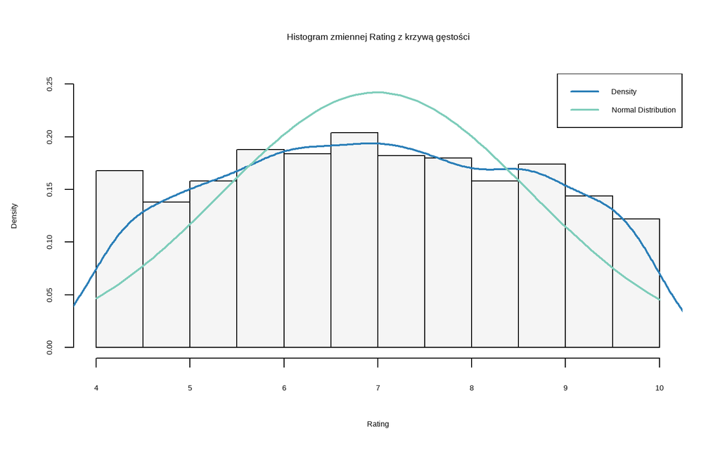

Na podstawie wyników wygenerowanych dzięki testom normalności można zauważyć, iż p-value dla każdego z testów przyjmuje wartość mniejszą niż 0.05, a zatem istnieją istotne statystycznie różnice między rozkładem danych a rozkładem normalnym. Zgodnie z powyższym należy odrzucić hipotezę zerową mówiącą o normalności rozkładu.

Zważywszy na ustalony brak normalności danych w dalszej analizie należy wykorzystać testy nieparametryczne.

## Korelacja Spearmana

Korelacja rang Spearmana to nieparametryczna alternatywa dla korelacji Pearsona, wykorzystywana do oceny siły i kierunku zależności między dwiema zmiennymi. Współczynnik korelacji Spearmana mierzy, jak dobrze monotonicznie (czyli w sposób ciągły rosnący lub malejący) zmieniają się wartości jednej zmiennej w zależności od drugiej. Jeśli współczynnik korelacji jest bliski 1 lub -1, oznacza to silny związek, natomiast wartość bliska 0 wskazuje na brak monotonicznej zależności.

**H0: zmienne są niezależne, a współczynnik korelacji Spearmana wynosi 0**

**H1: zmienne są zależne, a współczynnik korelacji Spearmana jest różny od 0**

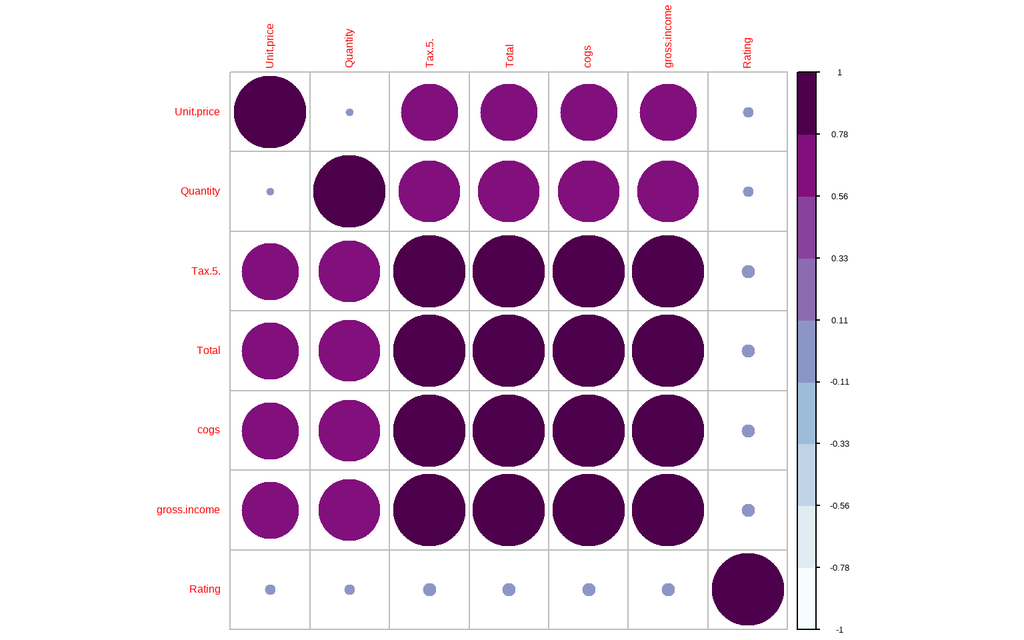

Wyniki korelacji wskazują, że cena jednostkowa, liczba zakupionych produktów, podatek, całkowita cena, koszty sprzedanych towarów oraz dochód brutto są ze sobą silnie powiązane, co wynika z ich bezpośredniego związku z transakcjami finansowymi. Wyższa cena jednostkowa i większa liczba produktów prowadzą do wzrostu pozostałych wartości. Natomiast oceny klientów (Rating) wykazują minimalną korelację z innymi zmiennymi, sugerując, że są one bardziej subiektywne i niezależne od wyników transakcji. W rezultacie, zależności między zmiennymi koncentrują się głównie na aspektach finansowych, podczas gdy oceny klientów pozostają mniej związane z tymi parametrami.

## Test Wilcoxona

Test Wilcoxona jest testem statystycznym zaliczanym do metod nieparametrycznych, wykorzystywanym do porównywania dwóch grup, zwłaszcza gdy dane nie spełniają założeń normalności rozkładu. Test analizuje rangowe wartości danych, co pozwala mu działać niezależnie od rozkładu zmiennych i sprawia, że jest mniej podatny na wpływ wartości odstających. Dzięki temu wykorzystywany jest w przypadkach, gdy dane mają nietypowe rozkłady, tak jak w przypadku danych ze zbioru *superstore*.

**H0: mediany obu grup są równe**

**H1: mediany obu grup różnią się**

```r
wilcox.test(super$Rating, super$Total)
```

```
##
##  Wilcoxon rank sum test with continuity correction
##
## data:  super$Rating and super$Total
## W = 0, p-value <0.0000000000000002
## alternative hypothesis: true location shift is not equal to 0
```

## Test Kruskala-Wallisa

Test Kruskala-Wallisa to nieparametryczny test statystyczny używany do porównywania median więcej niż dwóch grup niezależnych, gdy nie można założyć normalności rozkładu danych. Jest alternatywą dla jednoczynnikowej analizy wariancji (ANOVA)

**H0: mediany wszystkich porównywanych grup są równe**

**H1: przynajmniej jedna z median różni się od pozostałych**

*Ocena ~ Filia*

```
##
##  Kruskal-Wallis rank sum test
##
## data:  Rating by Branch
## Kruskal-Wallis chi-squared = 3.862, df = 2, p-value = 0.145
```

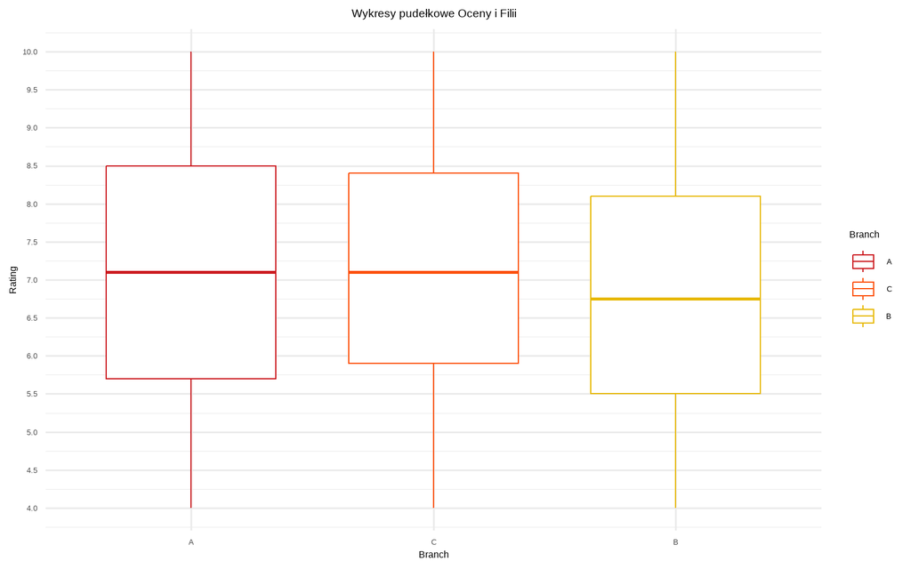

*Ocena ~ Sposób płatności*

```
##
##  Kruskal-Wallis rank sum test
##
## data:  Rating by Payment
## Kruskal-Wallis chi-squared = 0.459, df = 2, p-value = 0.795
```

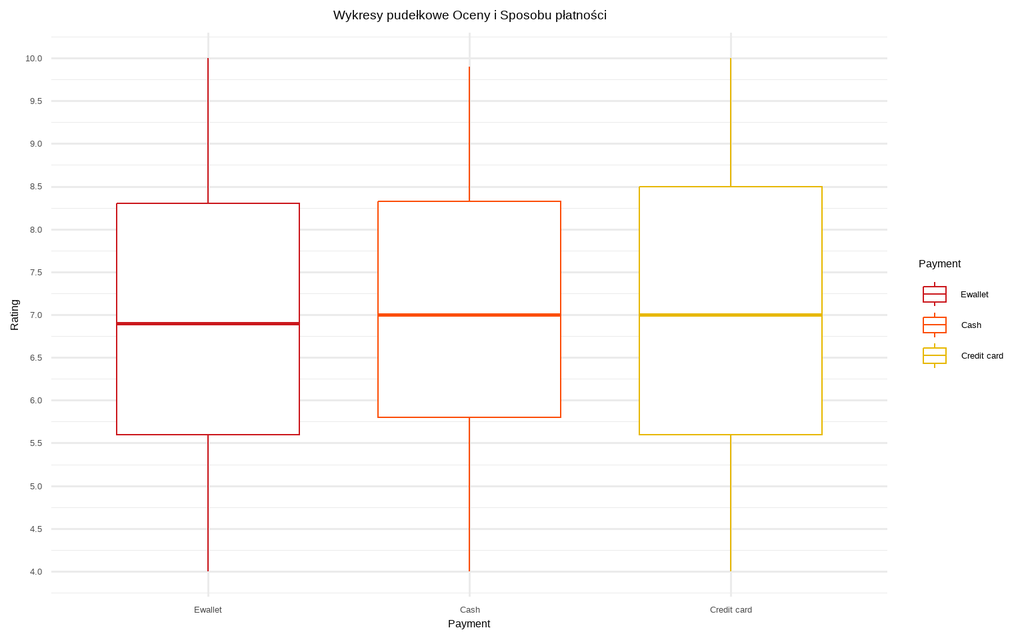

*Ocena ~ Miasto*

```
##
##  Kruskal-Wallis rank sum test
##
## data:  Rating by City
## Kruskal-Wallis chi-squared = 3.559, df = 2, p-value = 0.169
```

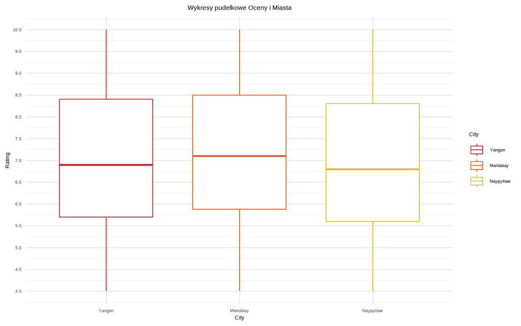

We wszystkich badanych przypadkach testy wykazały, iż p-value wyniosło więcej niż założony poziom istotności 0.05. Oznacza to, że nie mamy wystarczających dowodów, aby odrzucić hipotezę zerową. W praktyce nie ma istotnych statystycznie różnic między:

- medianami ocen doświadczenia zakupowego w trzech filiach
- medianami ocen doświadczenia zakupowego względem trzech możliwych sposobów płatności;
- medianami ocen doświadczenia zakupowego względem miast funkcjonowania sklepów.

Bazując na powyższych możemy stwierdzić, że filia, miasto czy sposób płatności nie mają istotnego wpływu na finalną ocenę zakupów przez klienta. Potwierdzeniem powyższych wyników są również wygenerowane wykresy pudełkowe, w których zakresy kwartylów są do siebie znacznie zbliżone.

# Testy porównawcze

## Test ANOVA dla filii sklepu

Test ANOVA (Analysis of Variance, analiza wariancji) jest stosowany w sytuacjach, gdy chce się sprawdzić, czy istnieją istotne różnice pomiędzy średnimi kilku grup.

**H0: Średnie wartości zmiennej zależnej w różnych filiach (Branch) są równe.**

**H1: Średnie wartości zmiennej zależnej różnią się pomiędzy co najmniej dwoma filiami.**

```
##              Df Sum Sq Mean Sq F value Pr(>F)
## Branch        2    243     121    0.88   0.41
## Residuals   997 136717     137
```

Następujące wyniki pokazują, że nie istnieje praktycznie żadna istotność pomiędzy oddziałem supercentrum a dochodem brutto. Wartość F jest bardzo niska - wynosi niecałe 1. Oznacza to, że różnice w dochodach brutto między poszczególnymi filiami są bardzo małe, więc są nieistotne statystycznie. Wartość p wynosi dużo więcej niż umowny poziom istotności (zazwyczaj jest to 0.05).

## Test ANOVA dla wybranej metody płatności

**H0: Średnie wartości zmiennej zależnej są takie same dla wszystkich metod płatności.**

**H1: Co najmniej jedna średnia różni się od pozostałych.**

```
##              Df Sum Sq Mean Sq F value Pr(>F)
## Payment       2     22    11.1    0.08   0.92
## Residuals   997 136937   137.3
```

Bardzo niska wartość F sugeruje, że różnice między grupami (metodami płatności) są minimalne w porównaniu do różnic wewnątrz grup. Wartość p jest znacznie większa niż przyjęty poziom istotności (zwykle 0,05). Oznacza to, że nie mamy podstaw do odrzucenia hipotezy zerowej.Test ANOVA nie wykazał statystycznie istotnych różnic pomiędzy średnimi wartościami zmiennej zależnej dla różnych metod płatności.Metoda płatności nie ma istotnego wpływu na analizowaną zmienną.

# Podsumowanie i wnioski

W procesie oczyszczania i przygotowania danych usunięto braki oraz zweryfikowano poprawność wartości, zapewniając spójność zbioru. Zastosowano różne techniki imputacji: sekwencyjną dla City, KNN dla Rating oraz obliczeniową dla gross.income. Finalnie przeprowadzono walidację, wykrywając i korygując błędne wartości w Total. Dzięki temu dane były kompletne, poprawne i gotowe do dalszej analizy.

W przeprowadzonej analizie statystycznej oceniono różne aspekty sprzedaży oraz doświadczeń zakupowych klientów na podstawie testów normalności, korelacji i testów porównawczych.

Badanie normalności wykazało, że rozkład ocen klientów (Rating) odbiega od normalnego, co potwierdziły testy statystyczne i wizualizacja histogramu. W związku z tym w dalszej analizie zastosowano metody **nieparametryczne**.

Test Kruskala-Wallisa wykazał, że filia, sposób płatności oraz miasto funkcjonowania sklepu nie wpływają istotnie na ocenę klientów. Dodatkowo analiza ANOVA nie ujawniła statystycznie istotnych różnic w dochodach brutto między filiami ani między różnymi metodami płatności.

Podsumowując, wyniki wskazują, że oceny klientów są subiektywne i nie zależą od czynników finansowych czy lokalizacyjnych, a sprzedaż w różnych filiach i przy różnych metodach płatności jest względnie stabilna.